# Usando Regressão Linear para Explicar a votação de Deputados

Diogo Florêncio

27 de novembro de 2017

```r
library(tidyverse)
library(ggplot2)
library(caret)
library(leaps)
options(scipen = 4)
dados <- read.csv("../dados/eleicoes2014.csv", encoding = "latin1")
```

### Um modelo de regressão múltipla com todas as variáveis é plausível para explicar a variação em y (número de votos)?

Para análisar se um modelo de regressão múltipla com todas as variáveis é plausível, estimei a proporção de quanto da variação da variável alvo `número de votos` o modelo consegue explicar (R²), também considerei o p-valor associado aos atributos. Caso o p-valor seja menor que 0,05, rejeita-se H0 com um nível de confiança de 95%, assim conclui-se que a variável explicativa tem correlação com a variável resposta.

```r
#gerando modelo de regressão múltipla
reg_linear =  lm(votos ~ sequencial_candidato + numero_cadidato + UF + partido
          + setor_economico_receita +  quantidade_doacoes+ quantidade_doadores + total_receita + media_receita
          + recursos_de_outros_candidatos.comites + recursos_de_partidos + recursos_de_pessoas_físicas
          + recursos_de_pessoas_juridicas + recursos_proprios + quantidade_despesas
          + quantidade_fornecedores + total_despesa + media_despesa + setor_economico_despesa
          + idade + sexo + grau + estado_civil, data = dados)
summary(reg_linear)
```

```
Call:
lm(formula = votos ~ sequencial_candidato + numero_cadidato +
    UF + partido + setor_economico_receita + quantidade_doacoes +
    quantidade_doadores + total_receita + media_receita + recursos_de_outros_candidatos.comites +
    recursos_de_partidos + recursos_de_pessoas_físicas + recursos_de_pessoas_juridicas +
    recursos_proprios + quantidade_despesas + quantidade_fornecedores +
    total_despesa + media_despesa + setor_economico_despesa +
    idade + sexo + grau + estado_civil, data = dados)

Residuals:
    Min      1Q  Median      3Q     Max
-244160  -22636     -19   25046  880867

Coefficients: (1 not defined because of singularities)
                                                                                                                                Estimate Std. Error t value
(Intercept)                                                                                                                    6.295e+05  4.675e+05   1.347
sequencial_candidato                                                                                                          -5.336e-08  2.601e-07  -0.205
numero_cadidato                                                                                                               -1.925e+02  1.765e+02  -1.090
UFAL                                                                                                                           4.332e+04  7.001e+04   0.619
UFAM                                                                                                                           8.290e+03  5.936e+04   0.140
UFAP                                                                                                                           1.707e+04  9.790e+04   0.174
UFBA                                                                                                                           4.130e+04  5.213e+04   0.792
UFCE                                                                                                                           3.116e+02  5.819e+04   0.005
UFDF                                                                                                                           1.001e+03  5.283e+04   0.019
UFES                                                                                                                           2.672e+04  4.902e+04   0.545
UFGO                                                                                                                           1.977e+04  4.752e+04   0.416
UFMA                                                                                                                           3.495e+04  5.369e+04   0.651
UFMG                                                                                                                           3.890e+04  3.670e+04   1.060
UFMS                                                                                                                          -1.385e+04  4.556e+04  -0.304
UFMT                                                                                                                           2.712e+04  5.567e+04   0.487
UFPA                                                                                                                           4.579e+04  4.223e+04   1.084
UFPB                                                                                                                           1.181e+04  4.470e+04   0.264
UFPE                                                                                                                           1.293e+05  6.430e+04   2.011
UFPI                                                                                                                           5.857e+04  4.493e+04   1.303
UFPR                                                                                                                           3.084e+04  3.569e+04   0.864
UFRJ                                                                                                                          -6.537e+03  3.511e+04  -0.186
UFRN                                                                                                                           6.870e+03  5.241e+04   0.131
UFRO                                                                                                                           8.092e+03  4.574e+04   0.177
UFRR                                                                                                                          -5.039e+04  6.544e+04  -0.770
UFRS                                                                                                                           3.317e+04  3.595e+04   0.923
```

[output cut: 164 more lines]

```
grauENSINO FUNDAMENTAL INCOMPLETO                                                                                                 0.8764
grauENSINO MÉDIO COMPLETO                                                                                                         0.7599
grauSUPERIOR COMPLETO                                                                                                             0.7029
grauSUPERIOR INCOMPLETO                                                                                                           0.5792
estado_civilDIVORCIADO(A)                                                                                                         0.6802
estado_civilSEPARADO(A) JUDICIALMENTE                                                                                             0.6720
estado_civilSOLTEIRO(A)                                                                                                           0.0510 .
estado_civilVIÚVO(A)                                                                                                              0.1656
---
Signif. codes:  0 ‘***’ 0.001 ‘**’ 0.01 ‘*’ 0.05 ‘.’ 0.1 ‘ ’ 1

Residual standard error: 77630 on 307 degrees of freedom
  (3748 observations deleted due to missingness)
Multiple R-squared:  0.4626,    Adjusted R-squared:  0.2945
F-statistic: 2.752 on 96 and 307 DF,  p-value: 1.973e-11
```

O modelo possui um R² = 0.4626, ou seja, 53.74% da variação em `número de votos` não é explicada. Também existem muitas variáveis com o p-valor muito elevado. Assim, considerando que nem metade da variação de `números de votos` é explicada e pelo p-valor elevado de muitas variáveis, concluo não ser plausível um modelo de regressão múltipla com todas as variáveis.

### Todas as variáveis são úteis para o modelo de regressão? Há variáveis redudantes?

Nem todas as variáveis são úteis para o modelo de regressão, como já demostrado na questão anterior por meio do p-valor. Para determinar se existem variáveis explicativas redundantes analisei a correlação linear entre pares.

```r
#removendo variáveis desnecessárias
dados_tratados <- dados %>% select(-nome, -sequencial_candidato, -numero_cadidato, -cargo, -setor_economico_receita, -setor_economico_despesa, -UF)
#Convertendo variáveis categoricas em numéricas
dados_tratados$sexo <- as.numeric(dados_tratados$sexo)
dados_tratados$grau <- as.numeric(dados_tratados$grau)
dados_tratados$estado_civil <-as.numeric(dados_tratados$estado_civil)
dados_tratados$partido <-as.numeric(dados_tratados$partido)
#Calculando correlações
corr = cor(dados_tratados[, 1:19])
round(corr, 2)
```

```
                                      partido quantidade_doacoes quantidade_doadores total_receita media_receita recursos_de_outros_candidatos.comites
partido                                  1.00               0.03                0.04         -0.04         -0.08                                    NA
quantidade_doacoes                       0.03               1.00                0.86          0.60          0.12                                    NA
quantidade_doadores                      0.04               0.86                1.00          0.46          0.09                                    NA
total_receita                           -0.04               0.60                0.46          1.00          0.60                                    NA
media_receita                           -0.08               0.12                0.09          0.60          1.00                                    NA
recursos_de_outros_candidatos.comites      NA                 NA                  NA            NA            NA                                     1
recursos_de_partidos                       NA                 NA                  NA            NA            NA                                    NA
recursos_de_pessoas_físicas                NA                 NA                  NA            NA            NA                                    NA
recursos_de_pessoas_juridicas              NA                 NA                  NA            NA            NA                                    NA
recursos_proprios                          NA                 NA                  NA            NA            NA                                    NA
votos                                   -0.04               0.48                0.42          0.62          0.43                                    NA
quantidade_despesas                     -0.02               0.58                0.48          0.81          0.38                                    NA
quantidade_fornecedores                 -0.01               0.50                0.44          0.72          0.33                                    NA
total_despesa                           -0.04               0.60                0.46          0.99          0.59                                    NA
media_despesa                           -0.07               0.14                0.13          0.37          0.54                                    NA
idade                                   -0.04               0.07                0.06          0.10          0.12                                    NA
sexo                                     0.00               0.14                0.12          0.14          0.14                                    NA
grau                                    -0.05               0.13                0.12          0.15          0.13                                    NA
estado_civil                             0.02              -0.11               -0.11         -0.11         -0.10                                    NA
                                      recursos_de_partidos recursos_de_pessoas_físicas recursos_de_pessoas_juridicas recursos_proprios votos
partido                                                 NA                          NA                            NA                NA -0.04
quantidade_doacoes                                      NA                          NA                            NA                NA  0.48
quantidade_doadores                                     NA                          NA                            NA                NA  0.42
total_receita                                           NA                          NA                            NA                NA  0.62
media_receita                                           NA                          NA                            NA                NA  0.43
recursos_de_outros_candidatos.comites                   NA                          NA                            NA                NA    NA
recursos_de_partidos                                     1                          NA                            NA                NA    NA
recursos_de_pessoas_físicas                             NA                           1                            NA                NA    NA
recursos_de_pessoas_juridicas                           NA                          NA                             1                NA    NA
recursos_proprios                                       NA                          NA                            NA                 1    NA
votos                                                   NA                          NA                            NA                NA  1.00
quantidade_despesas                                     NA                          NA                            NA                NA  0.55
quantidade_fornecedores                                 NA                          NA                            NA                NA  0.46
total_despesa                                           NA                          NA                            NA                NA  0.61
media_despesa                                           NA                          NA                            NA                NA  0.30
idade                                                   NA                          NA                            NA                NA  0.09
sexo                                                    NA                          NA                            NA                NA  0.16
grau                                                    NA                          NA                            NA                NA  0.14
estado_civil                                            NA                          NA                            NA                NA -0.12
```

[output cut: 20 more lines]

### No caso de haver variáveis pouco explicativas e/ou redudantes, construa um novo modelo sem essas variáveis e o compare ao modelo com todas as variáveis (e.g. em termos de R2 e RSE).

```r
#Gerando modelo de regressão múltipla sem variáveis redundantes ou desnecessárias
reg_linear_tratada =  lm(formula = votos ~ ., dados_tratados, na.action = na.omit)
summary(reg_linear_tratada)
```

```
Call:
lm(formula = votos ~ ., data = dados_tratados, na.action = na.omit)

Residuals:
    Min      1Q  Median      3Q     Max
-334930  -27464   -8849   23642 1043831

Coefficients:
                                         Estimate  Std. Error t value    Pr(>|t|)
(Intercept)                            6176.45536 36424.93816   0.170     0.86544
partido                                 144.11502   458.20634   0.315     0.75330
quantidade_doacoes                     -170.73860   112.20612  -1.522     0.12892
quantidade_doadores                     413.48340   152.22151   2.716     0.00690 **
total_receita                             1.47870     0.76292   1.938     0.05333 .
media_receita                             0.07570     0.33882   0.223     0.82333
recursos_de_outros_candidatos.comites    -1.27324     0.76140  -1.672     0.09529 .
recursos_de_partidos                     -1.47640     0.76574  -1.928     0.05458 .
recursos_de_pessoas_físicas              -1.50743     0.76657  -1.966     0.04996 *
recursos_de_pessoas_juridicas            -1.46059     0.76504  -1.909     0.05698 .
recursos_proprios                        -1.48437     0.76386  -1.943     0.05271 .
quantidade_despesas                      71.69434    14.14011   5.070 0.000000618 ***
quantidade_fornecedores                 -50.51031    18.86441  -2.678     0.00773 **
total_despesa                            -0.01780     0.02037  -0.874     0.38271
media_despesa                             8.28562     3.33677   2.483     0.01345 *
idade                                   212.53810   355.11656   0.599     0.54986
sexo                                   5347.78728 11829.07680   0.452     0.65146
grau                                   -481.29104  3093.51550  -0.156     0.87645
estado_civil                          -7148.66993  3409.71208  -2.097     0.03668 *
---
Signif. codes:  0 ‘***’ 0.001 ‘**’ 0.01 ‘*’ 0.05 ‘.’ 0.1 ‘ ’ 1

Residual standard error: 77330 on 385 degrees of freedom
  (3748 observations deleted due to missingness)
Multiple R-squared:  0.3313,    Adjusted R-squared:  0.3001
F-statistic:  10.6 on 18 and 385 DF,  p-value: < 2.2e-16
```

### Analise plots de resíduos e verifique se há tendências nos erros.

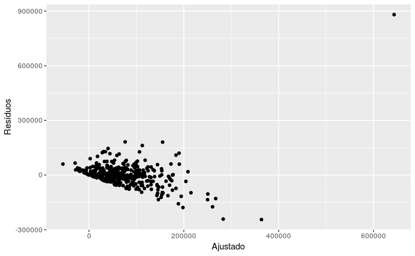

```r
ggplot(reg_linear, aes(x = .fitted, y = .resid)) +
  geom_point() +
  xlab("Ajustado") +
  ylab("Resíduos")
```

O gráfico exibe um padrão nos resíduos, evidenciando que o modelo não é ideal.

### Quais variáveis conseguem explicar melhor o número de votos?

As variáveis que mais explicam melhor o `numero de votos` são as que possuiem o menos p-valor e não tem uma forte correlação entre si.